# 9 CDOM harmonization process

Following the completion of the {dataRetrieval} download process described previously, the pipeline contains raw WQP data for each parameter of interest. Before we harmonize each parameter we run through a series of universal “pre-harmonization” steps, which ensure that the datasets are appropriately formatted when entering their harmonization routines.

The text below first walks through the pre-harmonization steps for the colored dissolved organic matter (CDOM) dataset and then delves into the specifics of the harmonization process.

## 9.1 Pre-harmonization of the raw CDOM WQP dataset

At the start of the pre-harmonization process the raw CDOM WQP dataset contains 186.4 thousand rows.

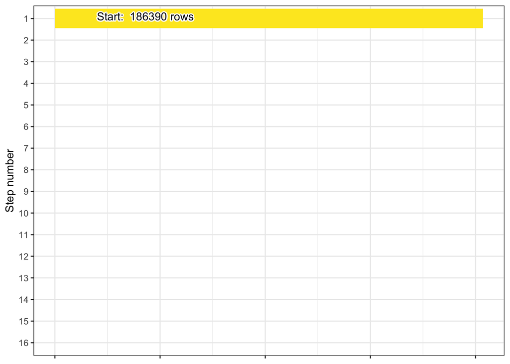

Bar plot showing the row count update for the current harmonization step.

### 9.1.1 Missing results

Next, records that have missing data are dropped from the dataset. Several criteria are used when checking for missing data. If any of the below criteria are met the row is flagged as missing:

1. Both the result column and detection limit column had `NA` data
2. Result, result unit, activity comment, laboratory comment, and result comment columns are all `NA`
3. The result comment column contains any user-provided text indicating a missing value. This currently includes: `analysis lost`, `not analyzed`, `not recorded`, `not collected`, or `no measurement taken`

473 rows are dropped, resulting in a final count of 185.9 thousand.

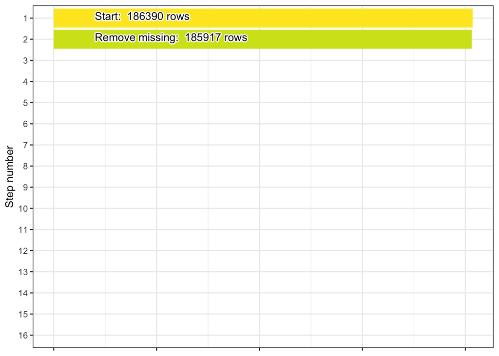

Bar plot showing the row count update for the current harmonization step.

### 9.1.2 Filter status

The final step in pre-harmonization is to filter the `ResultStatusIdentifier` column to include only the following statuses:

- `"Accepted"`
- `"Final"`
- `"Historical"`
- `"Validated"`
- `"Preliminary"`
- `NA`

These statuses generally indicate a reliable result was obtained, however we also include `NA` in an effort to be conservative. More specifically, when making decisions for this and other columns we occasionally retain `NA` values if removing the records would otherwise drop 10% or more of the available data.

This step removes 0 rows of data, leaving it with 185.9 thousand rows remaining.

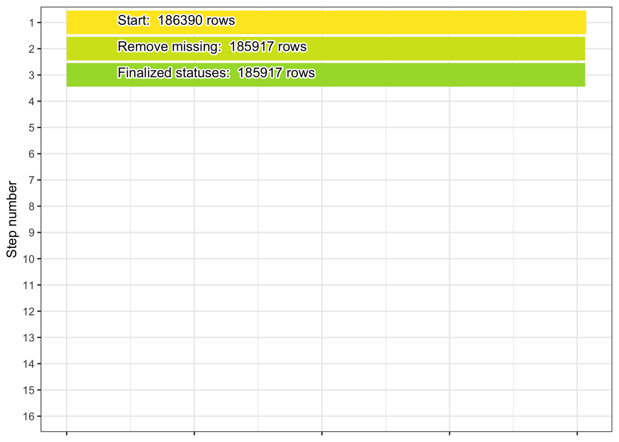

Bar plot showing the row count update for the current harmonization step.

## 9.2 Harmonization-ready CDOM dataset

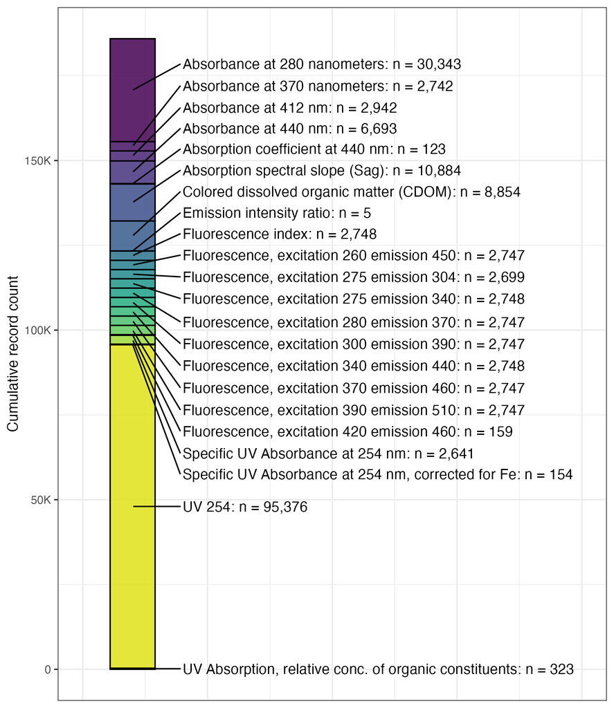

These `CharacteristicNames` are chosen in order to select for only those measurements that pertain to CDOM. We selected them by reviewing options in the `Characteristics` field of the [Water Quality Portal Filter Results](https://www.waterqualitydata.us/#advanced=true) page.

### 9.2.1 Filter media and fractions, categorize parameters

We next ensure that the media type for all CDOM data is `"Surface Water"`, `"Water"`, `"Estuary"`, or `NA`. Any records not meeting these criteria are dropped.

We then assign each record to one of the `parameter` values in the table below, based on its values for `CharacteristicName`, `ResultAnalyticalMethod.MethodName`, and `ResultMeasure.MeasureUnitCode`. This helps us to group comparable measurements throughout the rest of the process and generally simplify the way the dataset is organized:

[output not shown]

Records that do not meet the criteria of one of the `parameter` entries above are dropped (n = 1,113). A summary of the types of dropped records and their row counts is below:

```r
param_drop_record %>%
kable() %>%
  kable_paper() %>%
  scroll_box(width = "750px", height = "500px")
```

| CharacteristicName | ResultAnalyticalMethod.MethodName | USGSPCode | ResultAnalyticalMethod.MethodIdentifier | ResultAnalyticalMethod.MethodIdentifierContext | ResultMeasure.MeasureUnitCode | ResultSampleFractionText | n |
| --- | --- | --- | --- | --- | --- | --- | --- |
| Colored dissolved organic matter (CDOM) | 9222 B ~ Standard Total Coliform Membrane Filter Procedure | NA | 9222B | APHA | ug/L | NA | 7 |
| Colored dissolved organic matter (CDOM) | CHROMOPHORIC DISSOLVED ORGANIC MATTER | NA | NASA-CDOM | 21VASWCB | None | Dissolved | 839 |
| Colored dissolved organic matter (CDOM) | NASA/TM-2003-211621/Rev4-Vol.IV | NA | NASA/TM-2003-211621 | RTI | m | NA | 96 |
| Colored dissolved organic matter (CDOM) | NA | 32295 | NA | NA | NA | Dissolved | 2 |
| Colored dissolved organic matter (CDOM) | NA | 32322 | NA | NA | NA | Total | 2 |
| Colored dissolved organic matter (CDOM) | NA | NA | NA | NA | m | NA | 130 |
| Emission intensity ratio | Fluorescence scan, 250-620 nm | 32347 | FL020 | USGS | None | Dissolved | 5 |
| UV Absorption, relative conc. of organic constituents | UNKNOWN | NA | UNKNOWN | AZDEQ_SW | units/cm | Total | 32 |

Below is a stacked barplot of the dataset organized by the new `parameter` column:

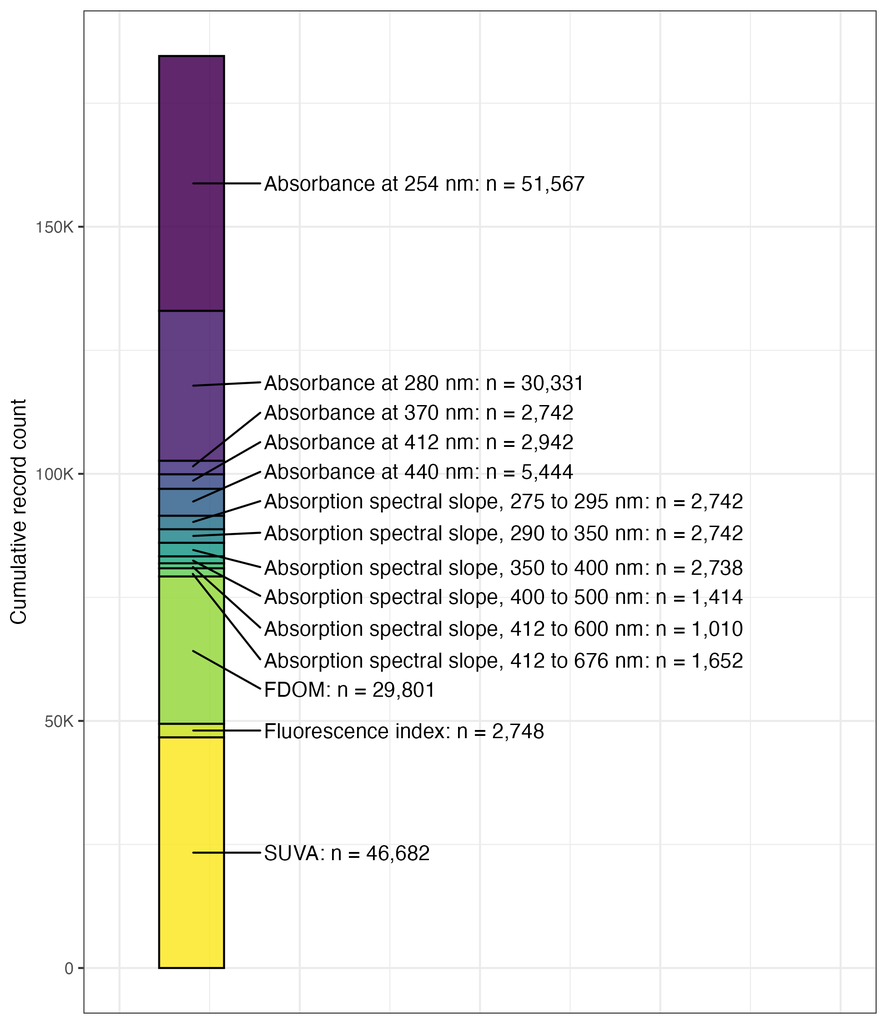

1.4 thousand rows are removed. The final row count after this is 184.6 thousand.

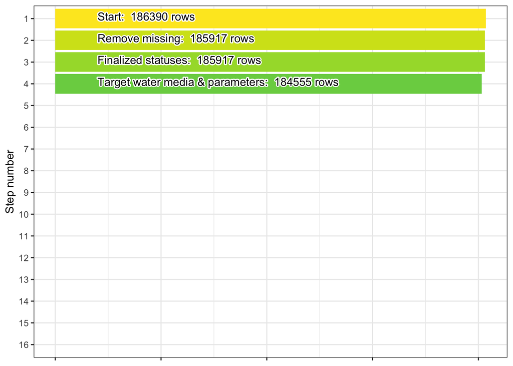

Bar plot showing the row count update for the current harmonization step.

### 9.2.2 Document and remove fails

In this step we filter out records based on indications that they have failed data quality assurance or quality control for some reason given by the data provider (these instances are referred to here as “failures”).

#### 9.2.2.1 ActivityCommentText fail detects

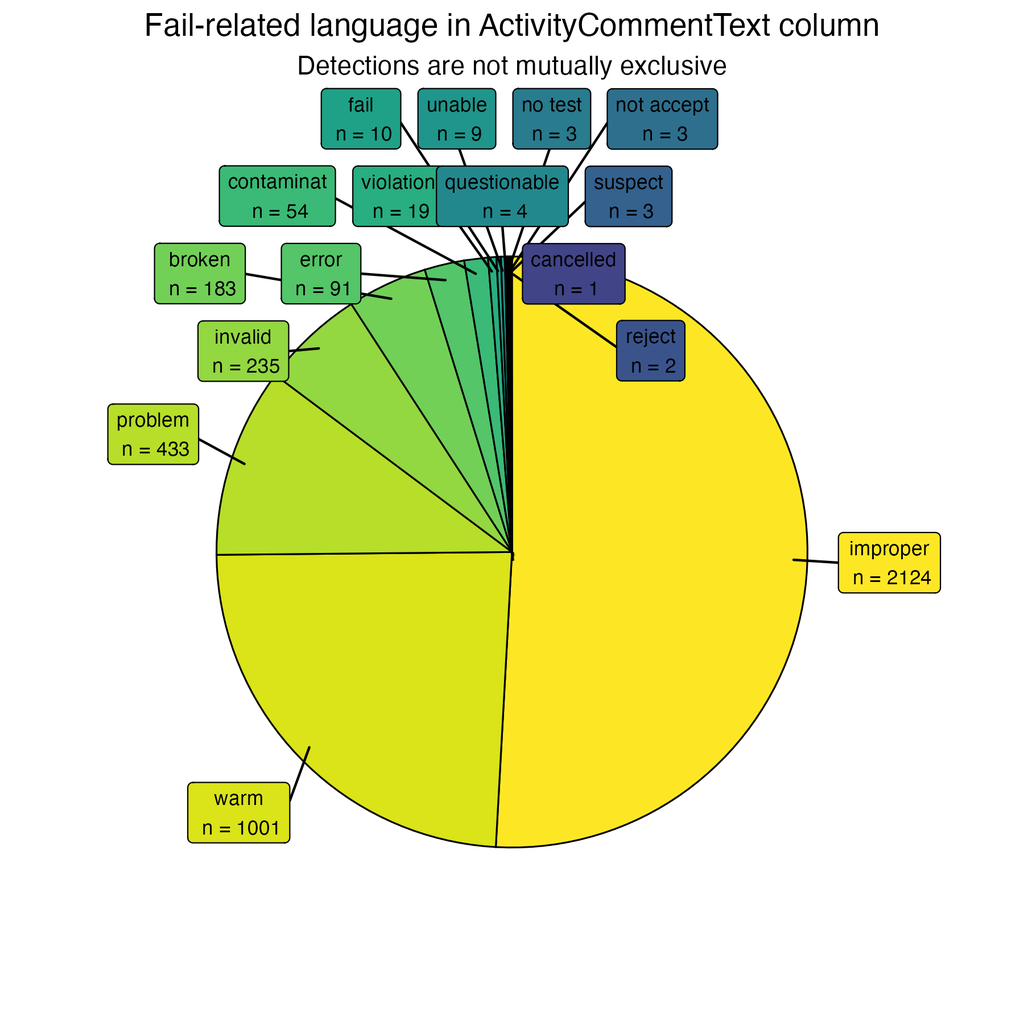

#### 9.2.2.2 ResultCommentText fail detects

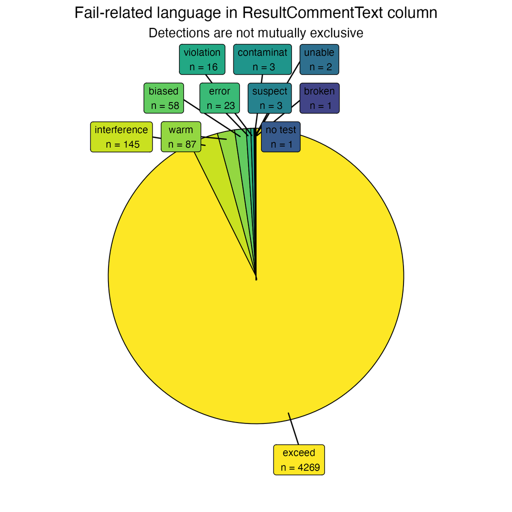

#### 9.2.2.3 ResultLaboratoryCommentText fail detects

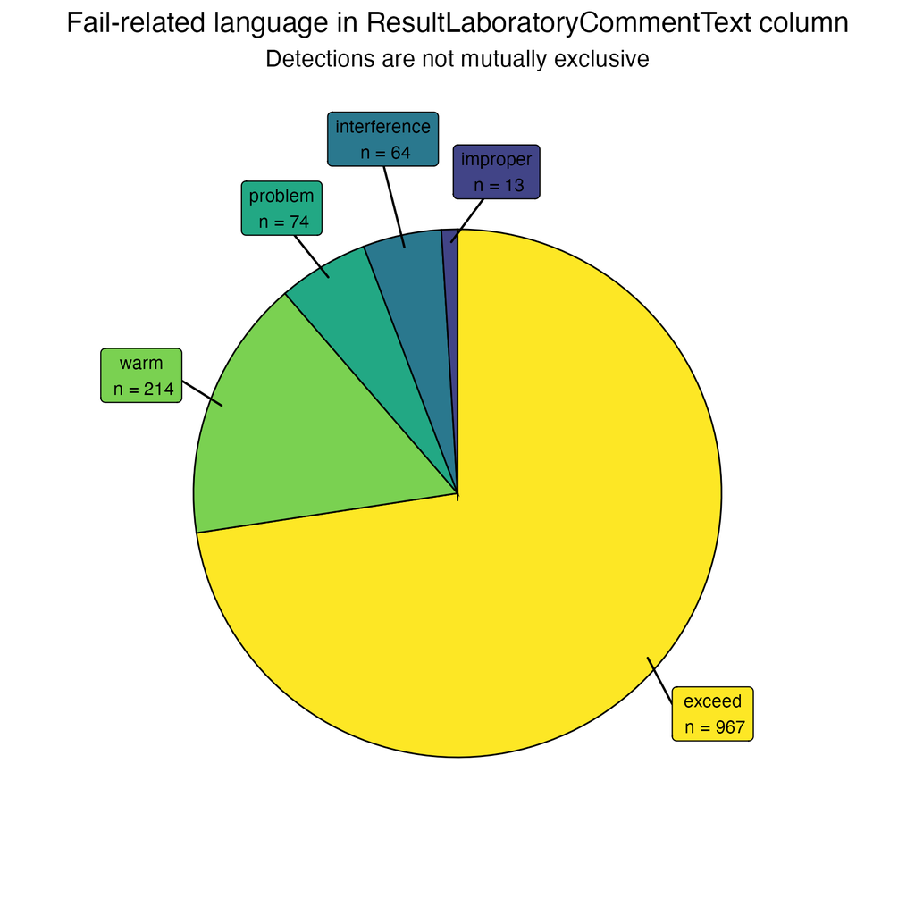

#### 9.2.2.4 ResultDetectionConditionText fail detects

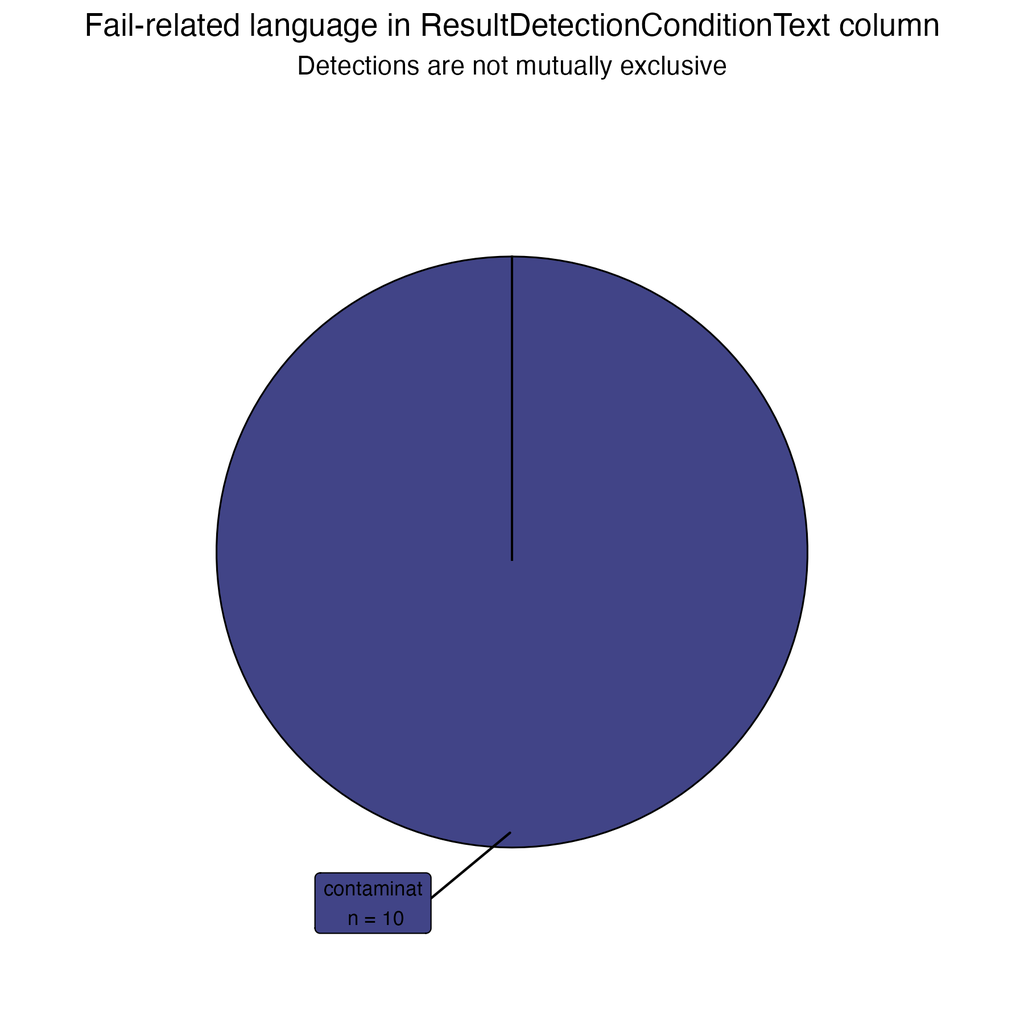

#### 9.2.2.5 ResultMeasureValue_original fail detects

[figure not shown]

8806 rows are removed after detecting failure-related phrases and 175.7 thousand rows remain.

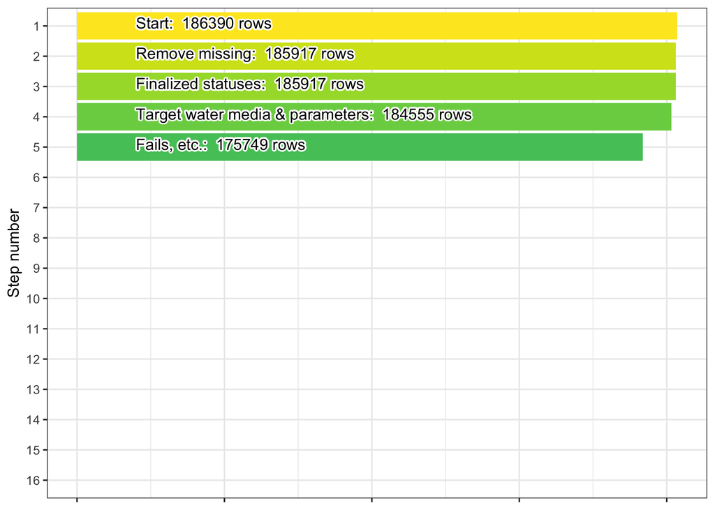

Bar plot showing the row count update for the current harmonization step.

### 9.2.3 Clean MDLs

In this step method detection limits (MDLs) are used to clean up the reported values. When a numeric value is missing for the data record (i.e., `NA` or text that became `NA` during an `as.numeric` call) we check for non-detect language in the `ResultLaboratoryCommentText`, `ResultCommentText`, `ResultDetectionConditionText`, and `ResultMeasureValue` columns. This language can be `"non-detect"`, `"not detect"`, `"non detect"`, `"undetect"`, or `"below"`.

If non-detect language exists then we use the `DetectionQuantitationLimitMeasure.MeasureValue` column for the MDL. Otherwise if there is a `<` and a number in the `ResultMeasureValue` column, we use that number instead.

We then use a random number between 0 and `0.5 * MDL` as the record’s value moving forward.

We produce a new column, `mdl_flag`, from the MDL cleaning process. Records where no MDL-based adjustment was made and which are at or above the MDL are assigned a 0. Records with corrected values based on the MDL method are assigned a 1. Finally, records where no MDL-based adjustment was made and which contain a numeric value below the provided MDL are assigned a 2.

This should not result in a change in rows, but we still check: 0 rows are removed. The final row count after this is 175.7 thousand.

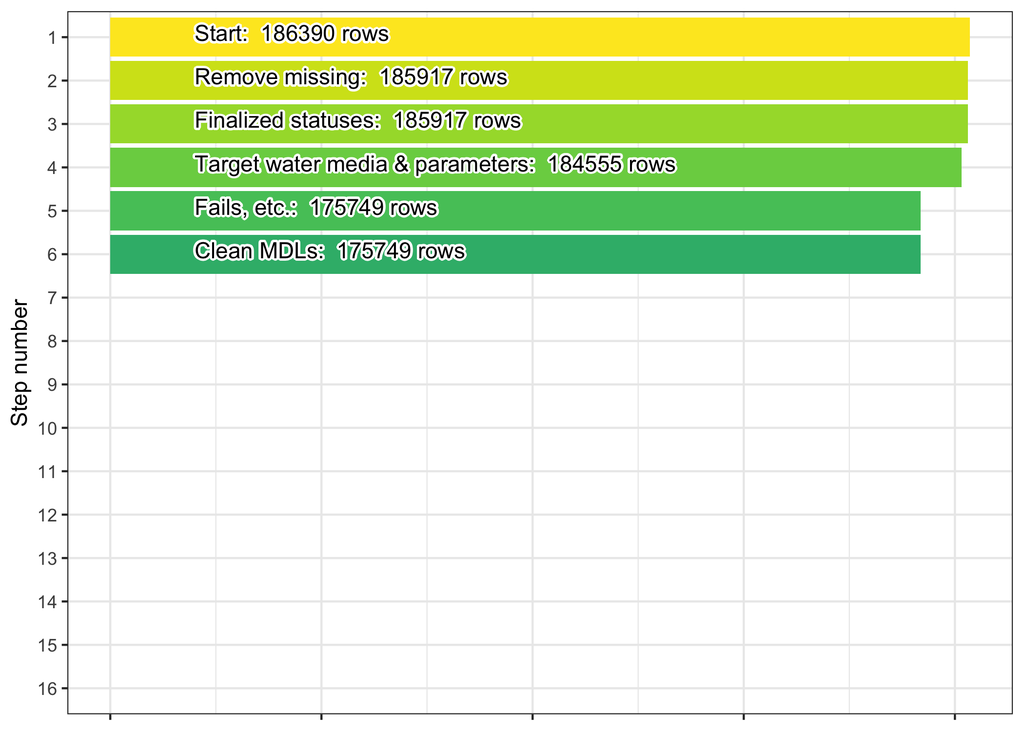

Bar plot showing the row count update for the current harmonization step.

### 9.2.4 Clean approximate values

Cleaning approximate values involves a similar process as for MDL cleaning. We flag “approximated” values in the dataset. The `ResultMeasureValue` column gets checked for **all** three of the following conditions:

1. Numeric-only version of the column is still `NA` after MDL cleaning
2. The original column text contained a number
3. Any of `ResultLaboratoryCommentText`, `ResultCommentText`, or `ResultDetectionConditionText` match this regular expression, ignoring case: `"result approx|RESULT IS APPROX|value approx"`

We then use the approximate value as the record’s value moving forward.

Records with corrected values based on the above method are noted with a 1 in the `approx_flag` column. Note, however, that occasionally approximate language will be used in a record but not changed or flagged. This occurs when the language is used in a comment-related column and **not** the result column itself, meaning that there is a usable numeric value provided (and thus doesn’t need correction).

This should not result in a change in rows, but we still check: 0 rows are removed. The final row count after this is 175.7 thousand.

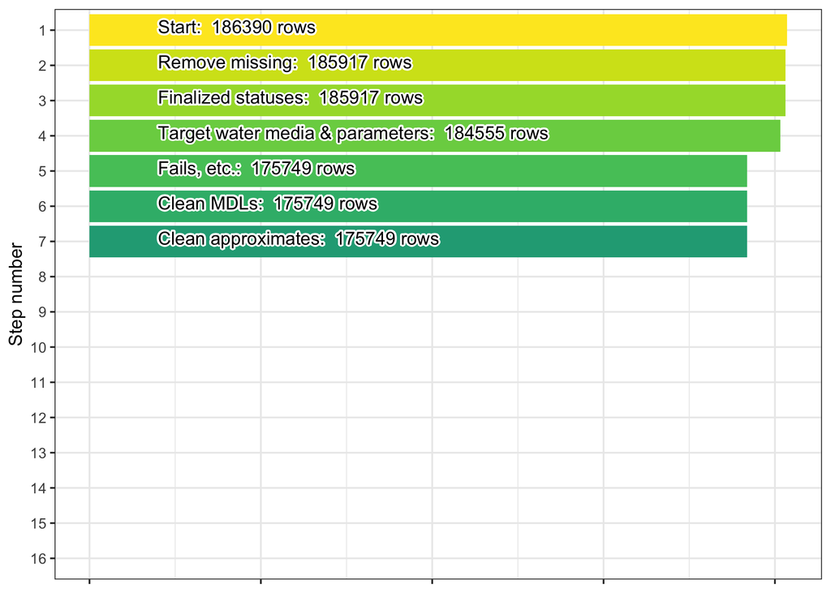

Bar plot showing the row count update for the current harmonization step.

### 9.2.5 Clean values with “greater than” data

The next step is similar to the MDL and approximate value cleaning processes, and follows the approximate cleaning process most closely. The goal is to clean up values that were entered as “greater than” some value. The `ResultMeasureValue` column gets checked for **all** three of the following conditions:

1. Numeric-only version of the column is still `NA` after MDL & approximate cleaning
2. The original column text contained a number
3. The original column text contained a `>`

We then use the “greater than” value (without `>`) as the record’s value moving forward.

Records with corrected values based on the above method are noted with a 1 in the `greater_flag` column.

This should not result in a change in rows, but we still check: 0 rows are removed. The final row count after this is 175.7 thousand.

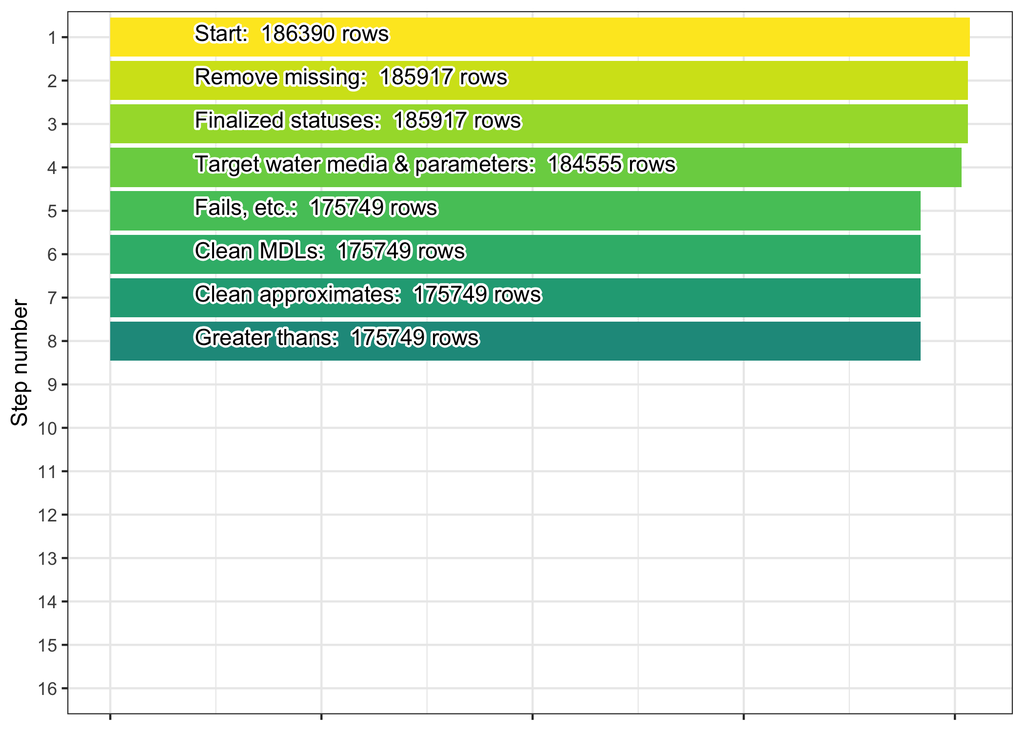

Bar plot showing the row count update for the current harmonization step.

### 9.2.6 Drop unresolved NA measurements

The goal of the preceding three steps was to prevent records with seemingly missing measurement data from being dropped if there was still a chance of recovering a usable value. At this point we’ve finished with that process and we proceed to check for remaining records with `NA` values in their `harmonized_value` column. If they exist, they are dropped. We also filter out any negative values in the dataset at this point because CDOM cannot be negative. The exception to this is for the “Absorption spectral slope” parameters, which we take the absolute value of instead of removing.

6 rows are removed. The final row count after this is 175.7 thousand.

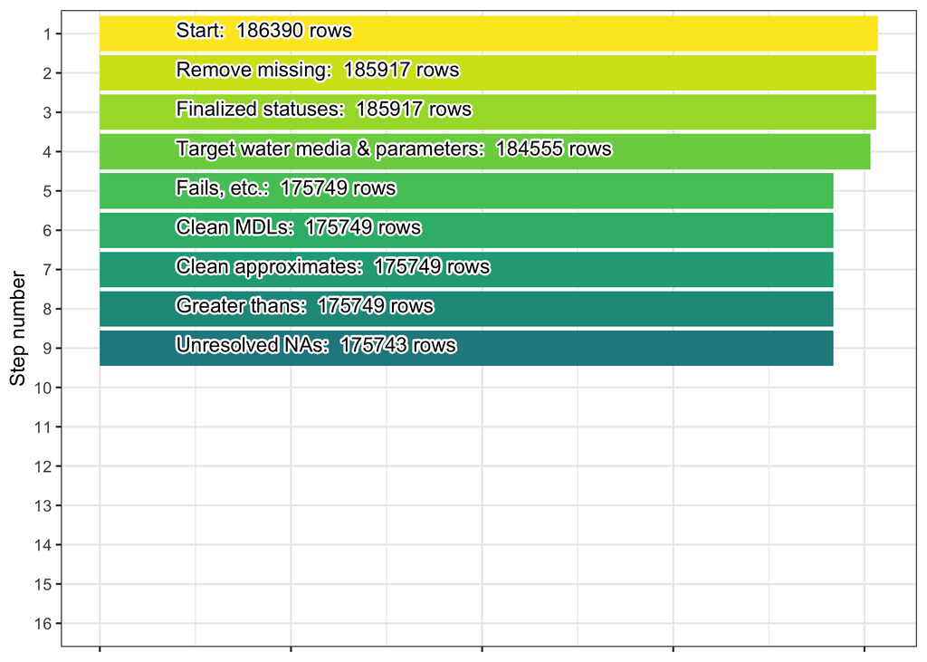

Bar plot showing the row count update for the current harmonization step.

### 9.2.7 Harmonize record units

The next step in CDOM harmonization is converting the units of WQP records. Records that don’t make sense for CDOM or can’t be converted to a standardized unit dropped. We standardize units to “AU/m” unless the `parameter` is “SUVA” (“L/mgDOC*m”), “FDOM” (“RFU”, “RU”, “ug/l QSE”), “Fluorescence index” (“None”), or one of the “Absorption spectral slope” variants (“nm-1”). We use the unit conversion table below for this.

| ResultMeasure.MeasureUnitCode | conversion |
| --- | --- |
| AU/cm | 100 |
| units/cm | 100 |
| #/cm | 100 |
| cm | 100 |
| None | 1 |
| nm | 100 |
| NA | 1 |
| m | 1 |
| L/mg-cm | 100 |
| L/mgDOC*m | 1 |
| mg/l | 1000 |
| ug/L | 1 |
| ug/l QSE | 1 |
| RFU | 1 |
| RU | 1 |
| per m | 1 |
| nm-1 | 1 |

**Note** that in the table above “nm” units are given a conversion factor of 100. This is because we assessed that these records are likely intended to use cm-1 units. For example: The `DetectionQuantitationLimitMeasure.MeasureUnitCode` for these records is “units/cm”, their measured values fall within expected ranges for natural waters for absorbance at 254 nm reported in cm-1 units, and the detection limit listed as 0.005 also aligns with cm-1 measurements. **Additionally** the table lists “None” with a conversion factor of 1, which allows it to be retained as-is for records with the “Fluorescence index” parameter. Records with parameter variants of “Absorption spectral slope” are often provided in the WQP with units of “None” as well, but we convert these to “nm-1” in this step.

Below is a pie chart that breaks down the different unit codes that were dropped in the unit harmonization process, and how many records were lost with each code. **(Note that if there is no pie chart below that is because no unit codes were dropped).**

[figure not shown]

0 rows are removed. The final row count after this is 175.7 thousand.

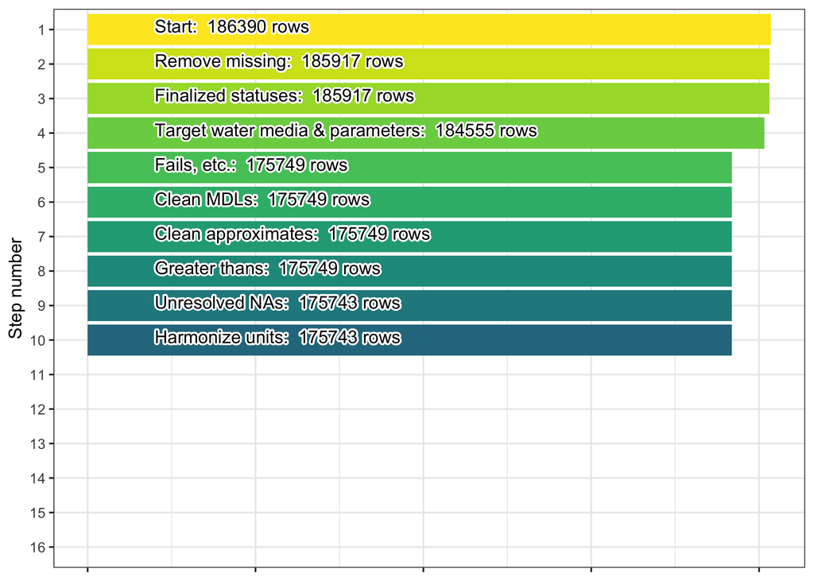

Bar plot showing the row count update for the current harmonization step.

### 9.2.8 Clean depth data

The next harmonization step cleans the four depth-related columns obtained from the WQP. The details behind this step are covered in the *Depth flags* section of the *Tiering, flagging, and quality control philosophy* chapter.

This should not result in a change in rows, but we still check: 0 rows are removed. The final row count after this is 175.7 thousand.

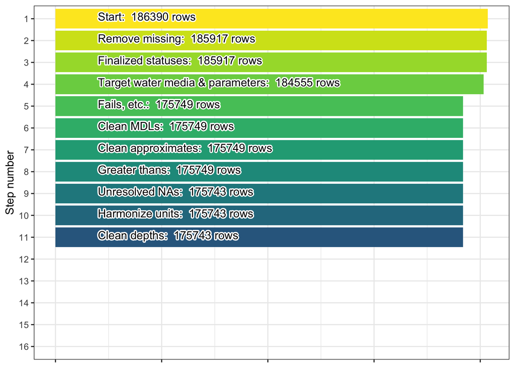

Bar plot showing the row count update for the current harmonization step.

### 9.2.9 Filter and tier methods

We next review information related to the analytical methods, sample fraction, and result units for each record to construct hierarchical tiers as described in the *Method tiering* section of the *Tiering, flagging, and quality control philosophy* chapter.

In preparation for tiering, we check the `ResultAnalyticalMethod.MethodName` column for names that indicate non-CDOM measurements.

Finally, we group the data into three tiers as described in *Tiering, flagging, and quality control philosophy*. Broadly, these tiers are:

| Tier | Name | Description | CDOM Details |
| --- | --- | --- | --- |
| 0 | Restrictive | Data that are verifiably self-similar across organizations and time-periods and can be considered highly reliable and interoperable | Has appropriate (and consistent) information in `CharacteristicName`, methods columns, and `ResultMeasure.MeasureUnitCode`. `ResultSampleFractionText` is filtered |
| 1 | Narrowed | Data that we have good reason to believe are self-similar, but for which we can’t verify full interoperability across data providers | There is a mismatch in information, e.g., between the methods columns |
| 2 | Inclusive | Data that are assumed to be reliable and are harmonized to our best ability given the information available from the data provider. This tier includes NA or non-resolvable descriptions for the analyti… | `ResultSampleFractionText` is reported as total or important information is missing from one or more relevant columns |

At this point we create a file (`in/cdom/cdom_tiering_record.csv`) that contains a record of how specific method text was tiered and how many row counts corresponded to each method. This file is also included as an interactive HTML table below, in order to illustrate how the specifics of each tiering decision in the table above are carried out.

```r
tiering_record %>%
kable() %>%
  kable_paper() %>%
  scroll_box(width = "750px", height = "500px")
```

| parameter | CharacteristicName | ResultAnalyticalMethod.MethodName | USGSPCode | ResultAnalyticalMethod.MethodIdentifier | ResultAnalyticalMethod.MethodIdentifierContext | ResultMeasure.MeasureUnitCode | ResultSampleFractionText | tier | min_value | max_value | n |
| --- | --- | --- | --- | --- | --- | --- | --- | --- | --- | --- | --- |
| SUVA | UV 254 | Computation by NWIS algorithm | 63162 | ALGOR | USGS | L/mgDOC*m | Dissolved | 0 | 0.0000000 | 1.980000e+02 | 37767 |
| Absorbance at 254 nm | UV 254 | UV Absorb, 254 nm, Supor (NWQL) | 50624 | UV006 | USGS | units/cm | Dissolved | 0 | 0.7000000 | 1.260000e+02 | 12301 |
| Absorbance at 254 nm | UV 254 | UV Absorb, 254 nm, GFF (NWQL) | 50624 | UV005 | USGS | units/cm | Dissolved | 0 | 1.0000000 | 6.320000e+02 | 12301 |
| Absorbance at 280 nm | Absorbance at 280 nanometers | UV Absorb, 280 nm, Supor (annon) | 61726 | UV002 | USGS | units/cm | Dissolved | 0 | 0.2000000 | 9.810000e+01 | 12272 |
| Absorbance at 280 nm | Absorbance at 280 nanometers | UV Absorb, 280 nm, GFF (NWQL) | 61726 | UV007 | USGS | units/cm | Dissolved | 0 | 0.7000000 | 4.950000e+02 | 12221 |
| Absorbance at 254 nm | UV 254 | UV absorbance, wf, 254 nm | 50624 | UV008 | USGS | units/cm | Dissolved | 0 | 0.0000000 | 1.905000e+02 | 6856 |
| Absorbance at 254 nm | UV 254 | UV Absorb, 254 nm,GFF (USGS-NYL) | 50624 | UV019 | USGS | units/cm | Dissolved | 0 | 0.3000000 | 1.680000e+02 | 5991 |
| Absorbance at 254 nm | UV 254 | NA | 50624 | NA | NA | units/cm | Dissolved | 0 | 0.0000000 | 2.140000e+02 | 4980 |
| SUVA | UV 254 | SUVA, wf, calculation | 63162 | UV003 | USGS | L/mgDOC*m | Dissolved | 0 | 0.1000000 | 1.000000e+01 | 4759 |
| Absorption spectral slope, 275 to 295 nm | Absorption spectral slope (Sag) | Sag, specified wavelength range | 32300 | ABS02 | USGS | None | Dissolved | 0 | 0.0077000 | 2.840000e-02 | 2680 |
| Absorbance at 280 nm | Absorbance at 280 nanometers | Absorbance, 200 to 800 nm | 32296 | ABS01 | USGS | AU/cm | Dissolved | 0 | 0.0700000 | 1.135000e+02 | 2678 |
| Absorbance at 370 nm | Absorbance at 370 nanometers | Absorbance, 200 to 800 nm | 32297 | ABS01 | USGS | AU/cm | Dissolved | 0 | 0.0000000 | 2.369000e+01 | 2676 |
| Absorption spectral slope, 290 to 350 nm | Absorption spectral slope (Sag) | Sag, specified wavelength range | 32301 | ABS02 | USGS | None | Dissolved | 0 | 0.0000000 | 2.770000e-02 | 2670 |
| Absorption spectral slope, 350 to 400 nm | Absorption spectral slope (Sag) | Sag, specified wavelength range | 32302 | ABS02 | USGS | None | Dissolved | 0 | 0.0071000 | 4.930000e-02 | 2662 |
| Absorbance at 440 nm | Absorbance at 440 nm | Absorbance, 200 to 800 nm | 32299 | ABS01 | USGS | AU/cm | Dissolved | 0 | 0.0500000 | 8.470000e+00 | 2639 |
| Absorbance at 412 nm | Absorbance at 412 nm | Absorbance, 200 to 800 nm | 32298 | ABS01 | USGS | AU/cm | Dissolved | 0 | 0.0500000 | 1.094000e+01 | 2629 |
| Fluorescence index | Fluorescence index | Fluorescence scan, 250-620 nm | 32312 | FL020 | USGS | None | Dissolved | 0 | 1.1340000 | 2.171000e+00 | 2476 |
| FDOM | Fluorescence, excitation 300 emission 390 | Fluorescence scan, 250-620 nm | 32309 | FL020 | USGS | RU | Dissolved | 0 | 0.0030000 | 5.971000e+00 | 2476 |
| FDOM | Fluorescence, excitation 340 emission 440 | Fluorescence scan, 250-620 nm | 52901 | FL020 | USGS | RU | Dissolved | 0 | 0.0010000 | 7.140000e+00 | 2474 |
| FDOM | Fluorescence, excitation 370 emission 460 | Fluorescence scan, 250-620 nm | 52902 | FL020 | USGS | RU | Dissolved | 0 | 0.0010000 | 5.260000e+00 | 2419 |
| FDOM | Fluorescence, excitation 260 emission 450 | Fluorescence scan, 250-620 nm | 32304 | FL020 | USGS | RU | Dissolved | 0 | 0.0096000 | 1.502000e+01 | 2379 |
| FDOM | Fluorescence, excitation 390 emission 510 | Fluorescence scan, 250-620 nm | 32307 | FL020 | USGS | RU | Dissolved | 0 | 0.0015000 | 3.236000e+00 | 2338 |
| FDOM | Fluorescence, excitation 280 emission 370 | Fluorescence scan, 250-620 nm | 32310 | FL020 | USGS | RU | Dissolved | 0 | 0.0117000 | 5.096000e+00 | 2319 |
| Absorbance at 254 nm | UV 254 | UV Absorb, 254 nm, silver (NWQL) | 50624 | UV004 | USGS | units/cm | Dissolved | 0 | 0.1000000 | 1.430000e+02 | 1990 |
| SUVA | UV 254 | NA | 63162 | NA | NA | L/mgDOC*m | Dissolved | 0 | 0.3000000 | 6.300000e+00 | 1809 |
| FDOM | Fluorescence, excitation 275 emission 340 | Fluorescence scan, 250-620 nm | 32311 | FL020 | USGS | RU | Dissolved | 0 | 0.0026000 | 3.517000e+00 | 1713 |
| Absorbance at 280 nm | Absorbance at 280 nanometers | UV Absorb, 280 nm,silver (annon) | 61726 | UV001 | USGS | units/cm | Dissolved | 0 | 0.1000000 | 9.930000e+06 | 1697 |
| FDOM | Colored dissolved organic matter (CDOM) | Colorized Dissolved Organic Matter | NA | FLUORO | COEOMAHA_WQX | ug/L | NA | 2 | 10.0000000 | 2.680000e+02 | 1683 |
| Absorbance at 254 nm | Specific UV Absorbance at 254 nm | 5910 B ~ UV - Absorbing Organic Compounds | NA | 5910-B | APHA | #/cm | Dissolved | 0 | 0.0008584 | 6.520000e+01 | 1577 |
| FDOM | Colored dissolved organic matter (CDOM) | Turner Designs Trilogy Fluorometer with CDOM specific excitation/emission filters for monitoring CDOM in natural waters | NA | TurnerDesigns-CDOM | 31DELRBC_WQX | RFU | Dissolved | 2 | 472.5600000 | 9.261500e+03 | 1557 |

[output cut: 78 more lines]

The above process drops 0 rows, leaving 175.7 thousand remaining.

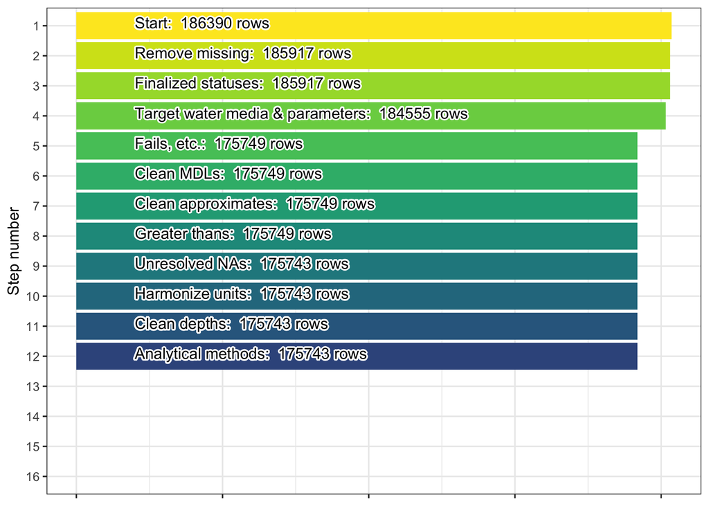

Bar plot showing the row count update for the current harmonization step.

### 9.2.10 Flag based on field methods

Next, we use the `field_flag` column to flag records based on the type of sampling equipment that was used:

- `field_flag` = `0` when discrete sampling methods were used. Indicated by detection of “grab”, “bucket”, “point”, “kemmerer”, “van dorn”, “bailer”, or “bottle” in `SampleCollectionEquipmentName`
- `field_flag` = `1` when integrated sampling methods were used. Indicated by detection of “integrated”, “multiple”, or “pump” in `SampleCollectionEquipmentName`
- `field_flag` = `2` for all other records

No records should be removed by this process and so there are 0 rows dropped leaving 175.7 thousand remaining in the harmonized CDOM dataset.

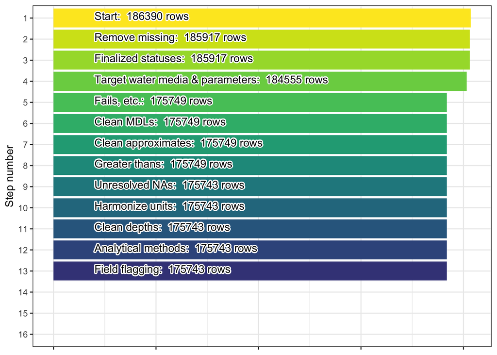

Bar plot showing the row count update for the current harmonization step.

### 9.2.11 Miscellaneous flag

Next, we populate the miscellaneous flag (`misc_flag`) column. The miscellaneous flag is used in this dataset to mark measurements that fall outside published maximum records based on a review of the relevant literature. We do this instead of filtering the records out, but a depth-related filter still occurs in the next harmonization step.

For this flag column, values are as follows: 0 = does not exceed published range, 1 = below published minimum, and 2 = above published maximum. Absorption spectral slope parameters, SUVA, and Fluorescence index are checked for values below minimum **or** above maximum published records, while the rest of the parameter options are just checked for values above published maximums. We use the absolute value of absorption spectral slope when testing against thresholds.

Thresholds used and citations are below, followed by a table with counts by parameters, unit, and flag value:

| **Parameter** | **Units** | **Min value** | **Max value** | **Source** |
| --- | --- | --- | --- | --- |
| Absorbance at 254 nm | AU/m | - | 450 | Yates et al. 2023 |
| Absorbance at 280 nm | AU/m | - | 36.1 | Korak and McKay 2024 |
| Absorbance at 370 nm | AU/m | - | 11 | Korak and McKay 2024 |
| Absorbance at 412 nm | AU/m | - | 14 | We use the threshold for 440 nm (below) as a conservative estimate |
| Absorbance at 440 nm | AU/m | - | 14 | Brezonik et al. 2019 |
| Absorption spectral slope (multiple) | nm-1 | 0.0026 | 0.0473 | Korak and McKay 2024 |
| FDOM | RU | - | 4.38 | Korak and McKay 2024 |
| FDOM | ug/L, ug/l QSE | - | 84.4 | Avouris et al. 2025 |
| Fluorescence index | None | 1.31 | 2.18 | Korak and McKay 2024 |
| SUVA | L/mgDOC*m | 0.651 | 6.83 | Korak and McKay 2024 |

| parameter | harmonized_units | misc_flag | n |
| --- | --- | --- | --- |
| Absorbance at 254 nm | AU/m | 0 | 49634 |
| Absorbance at 254 nm | AU/m | 2 | 3 |
| Absorbance at 280 nm | AU/m | 0 | 27431 |
| Absorbance at 280 nm | AU/m | 2 | 1525 |
| Absorbance at 370 nm | AU/m | 0 | 2653 |
| Absorbance at 370 nm | AU/m | 2 | 24 |
| Absorbance at 412 nm | AU/m | 0 | 2826 |
| Absorbance at 412 nm | AU/m | 2 | 2 |
| Absorbance at 440 nm | AU/m | 0 | 5347 |
| Absorbance at 440 nm | AU/m | 2 | 12 |
| Absorption spectral slope, 275 to 295 nm | nm-1 | 0 | 2681 |
| Absorption spectral slope, 275 to 295 nm | nm-1 | 1 | 3 |
| Absorption spectral slope, 290 to 350 nm | nm-1 | 0 | 2679 |
| Absorption spectral slope, 290 to 350 nm | nm-1 | 1 | 5 |
| Absorption spectral slope, 350 to 400 nm | nm-1 | 0 | 2671 |
| Absorption spectral slope, 350 to 400 nm | nm-1 | 1 | 8 |
| Absorption spectral slope, 350 to 400 nm | nm-1 | 2 | 1 |
| Absorption spectral slope, 400 to 500 nm | nm-1 | 0 | 1414 |
| Absorption spectral slope, 412 to 600 nm | nm-1 | 0 | 973 |
| Absorption spectral slope, 412 to 600 nm | nm-1 | 1 | 10 |
| Absorption spectral slope, 412 to 676 nm | nm-1 | 0 | 1543 |
| Absorption spectral slope, 412 to 676 nm | nm-1 | 1 | 51 |
| FDOM | RFU | 0 | 2955 |
| FDOM | RU | 0 | 18391 |
| FDOM | RU | 2 | 38 |
| FDOM | ug/L | 0 | 1719 |
| FDOM | ug/L | 2 | 633 |
| FDOM | ug/l QSE | 0 | 2053 |
| FDOM | ug/l QSE | 2 | 291 |
| Fluorescence index | None | 0 | 2628 |
| Fluorescence index | None | 1 | 37 |
| SUVA | L/mgDOC*m | 0 | 43998 |
| SUVA | L/mgDOC*m | 1 | 130 |
| SUVA | L/mgDOC*m | 2 | 1374 |

No records should be removed by this process and so there are 0 rows dropped leaving 175.7 thousand remaining in the harmonized CDOM dataset.

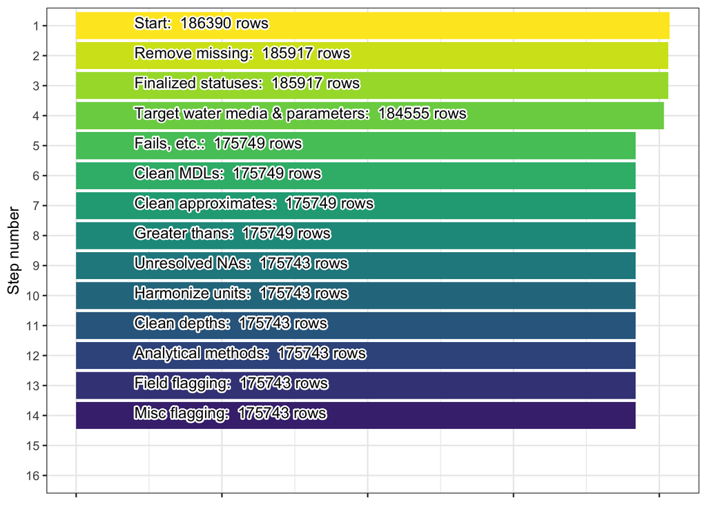

Bar plot showing the row count update for the current harmonization step.

### 9.2.12 Remove unrealistic values

Before finalizing the dataset we check for and remove any depths > 592m, the deepest point in a lake in the U.S.

0 rows are removed. The final row count after this is 175.7 thousand.

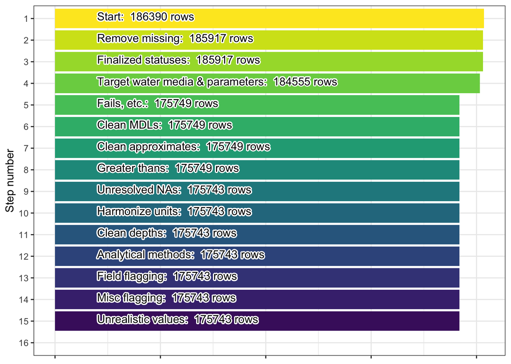

Bar plot showing the row count update for the current harmonization step.

### 9.2.13 Aggregate simultaneous records

The final step of CDOM harmonization is to aggregate simultaneous observations.

**The aggregation process**: Any group of samples determined to be simultaneous are simplified into a single record containing the mean and coefficient of variation (CV) of the group. These can be either true duplicate entries in the WQP or records with non-identical values recorded at the same time and place and by the same organization (field and/or lab replicates/duplicates). The CV can be used to filter the dataset based on the amount of variability that is tolerable to specific use cases. Note, however, that many entries will have a CV that is `NA` because there are no simultaneous records or 0 because the records are duplicates and all entries have the same `harmonized_value`.

We identify simultaneous records to aggregate by creating identical subgroups (`subgroup_id`) from the following columns: `parameter`, `OrganizationIdentifier`, `MonitoringLocationIdentifier`, `MonitoringLocationTypeName`, `ResolvedMonitoringLocationTypeName`, `ActivityStartDate`, `ActivityStartTime.Time`, `ActivityStartTime.TimeZoneCode`, `harmonized_tz`, `harmonized_local_time`, `harmonized_utc`, `ActivityStartDateTime`, `harmonized_top_depth_value`, `harmonized_top_depth_unit`, `harmonized_bottom_depth_value`, `harmonized_bottom_depth_unit`, `harmonized_discrete_depth_value`, `harmonized_discrete_depth_unit`, `depth_flag`, `mdl_flag`, `approx_flag`, `greater_flag`, `tier`, `field_flag`, `misc_flag`, `harmonized_units`. This selection limits the columns included in the final dataset, but we also provide a copy of the AquaMatch dataset prior to its aggregation (pipeline target `p3_cdom_preagg_grouped`; available as an RDS file in the data release: AquaMatch_harmonize_WQP/_targets/objects/p3_cdom_preagg_grouped), and include the `subgroup_id` column, so that users can use the disaggregated data as well and match make joins between dataset versions.

**Note**: We hold out any records where `misc_flag` is 1 or 2 from the aggregation step above, and as a result those records are *not* included in the `p3_cdom_preagg_grouped` object, nor its RDS export. The records are added back into the final dataset once the aggregation is complete, but they have `NA` for `subgroup_id`, `harmonized_value_cv`, and `harmonized_row_count` because they are never grouped or aggregated. We do this to allow end users to decide how they want to handle values that exceed published maximums.

The final values are presented in the `harmonized_value` and `harmonized_value_cv` columns. The number of rows used per group is recorded in the `harmonized_row_count` column.

1.6263^{4} rows dropped leaving 159.5 thousand remaining in the final harmonized and aggregated CDOM dataset.

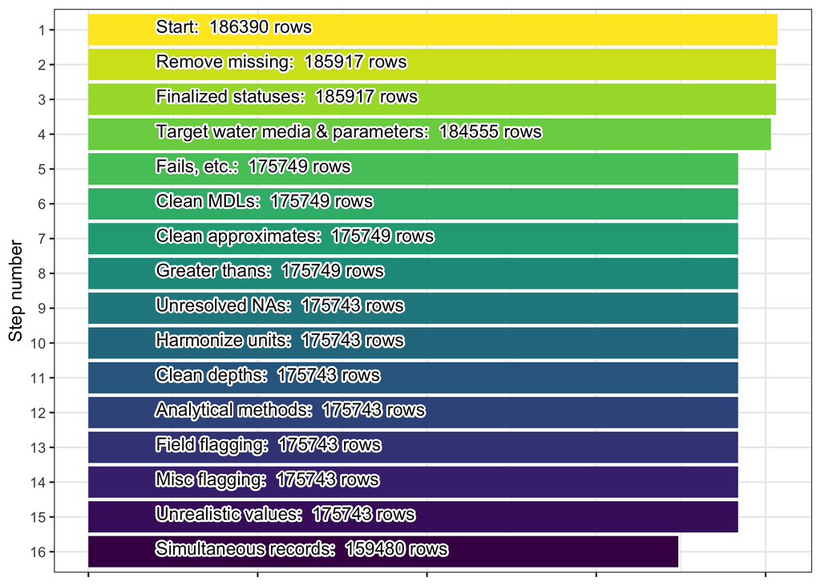

Bar plot showing the row count update for the current harmonization step.

### 9.2.14 Harmonized CDOM

At this point the harmonization of the CDOM data from the WQP is complete and we export the final dataset for use later in the workflow.

Below are several sets of figures illustrating different qualities of the dataset:

1. Histograms showing the distribution of harmonized measurements (top) and CVs (bottom) broken down by `tier` *after* aggregating simultaneous records. There are very few simultaneous records in the dataset, so only a few CVs are produced.

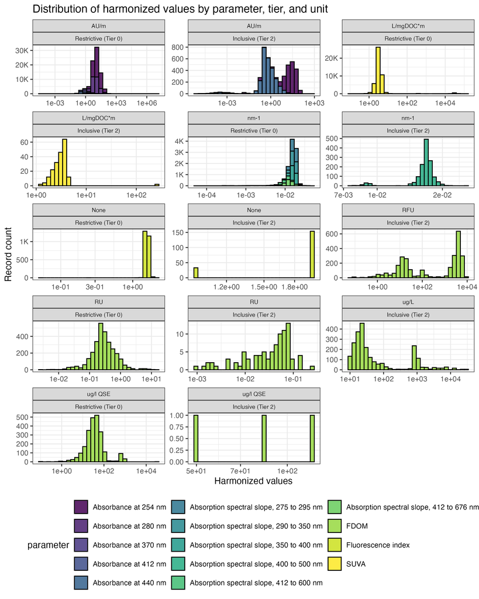

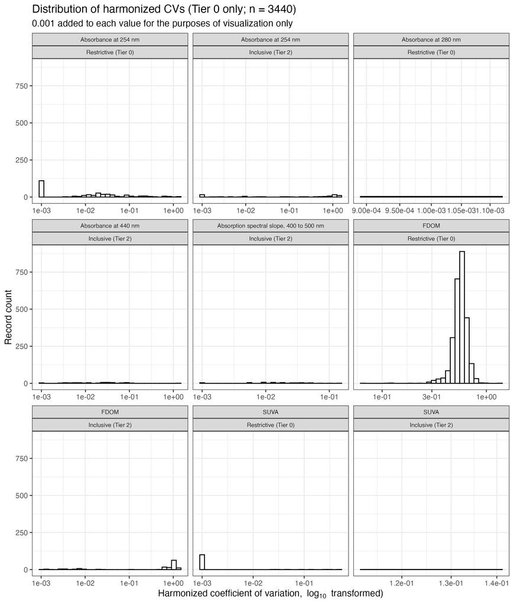

2. Maps showing the geographic distribution of records by tier within the US:

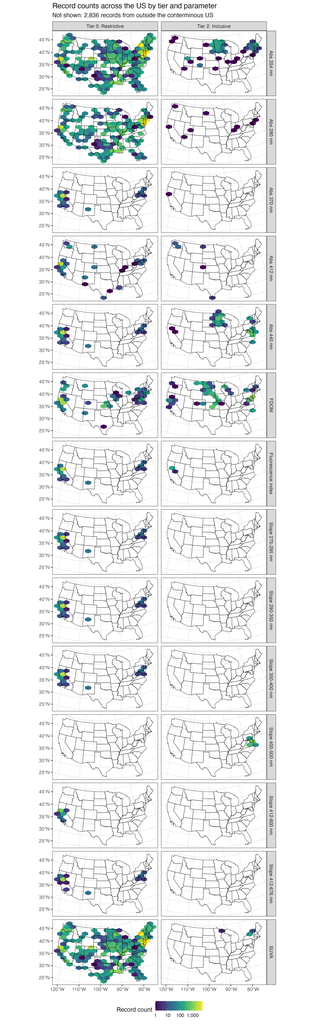

3. Bar charts showing the distribution of values by tier across years, months, and days of the week:

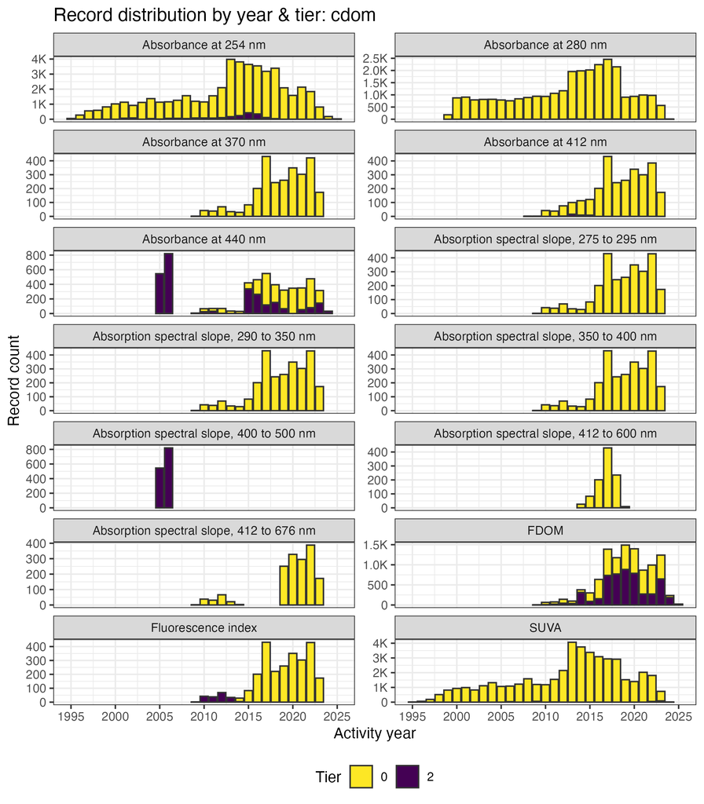

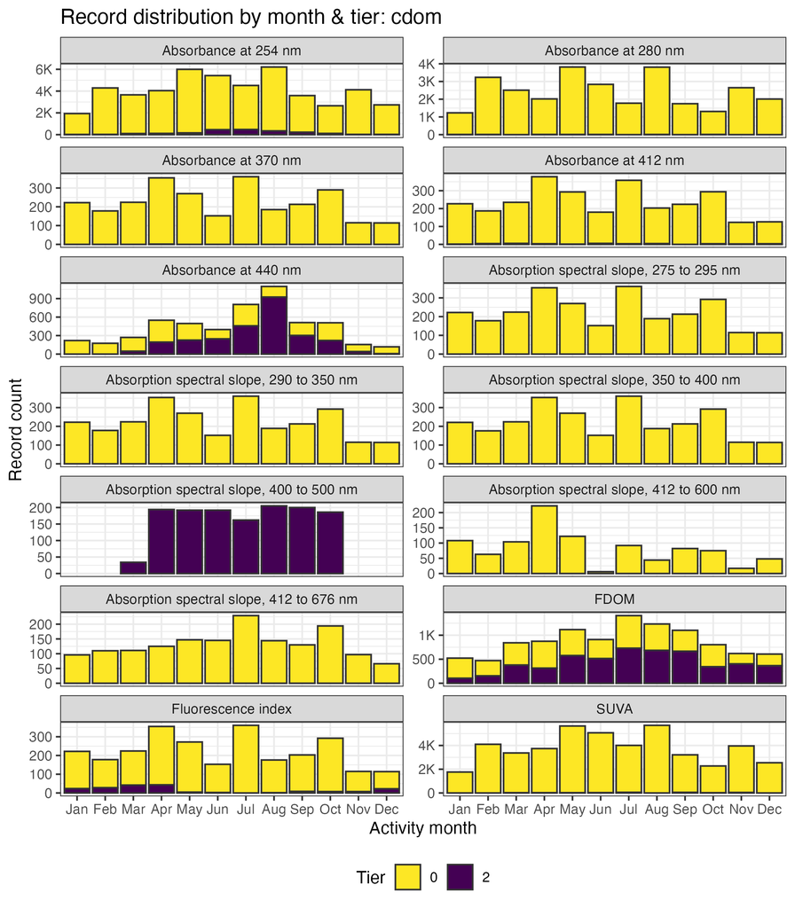

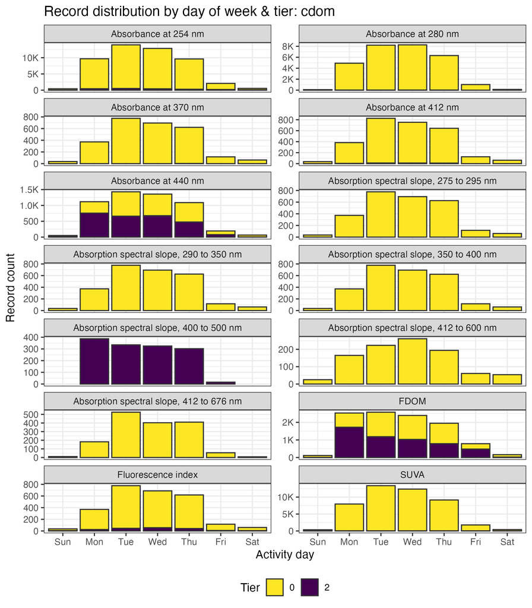

4. Lastly, bar charts showing the distribution of depth values by parameter, location type, and tier:

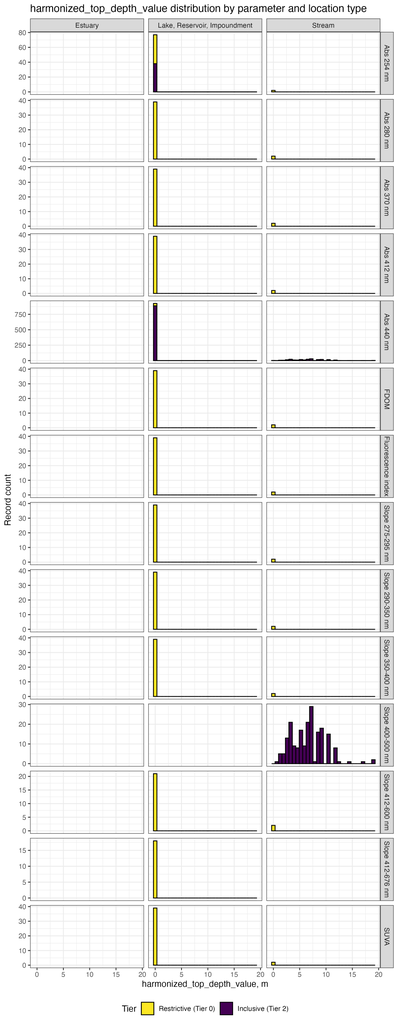

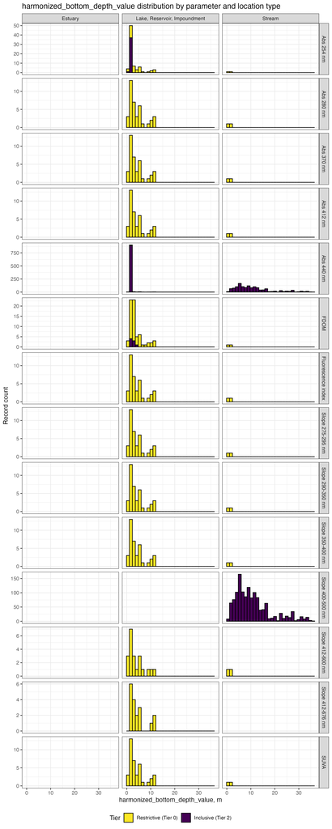

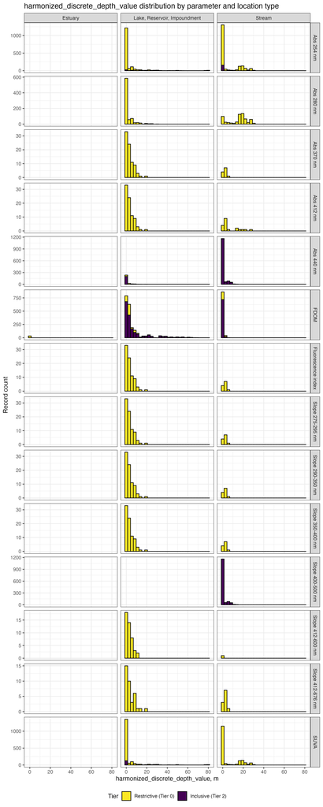